# Using Machine Learning to Predict NFL Betting Outcomes

Author

Jacob Lukasik & Michael Jenks

Published

December 9, 2024

# Preparation, Research, and Data Processing:

## What we want to find & our motivation

In this project, we have compiled a huge amount of information about the NFL and previous games’ information on betting lines and their results. With this data, we seek to build several predictive models for betting on the over or under. In sports betting, the over/under line is a number set by the betting market, and if the total score between both teams is greater than that number, then the over hits and then the under hits otherwise. We seek to use a classification model to determine this.

Our motivation to do this project came from not only our avid love of football, but also because we wanted to try and gain some insights into what goes into predicting sporting events’ outcomes. With the rise of sports betting in recent years since it became legal in many states in America, there has a been a boom in profit for the biggest sportsbooks in Vegas. We want to try and get a glimpse into what goes into betting successfully to the point where a bettor can make a profit, as well as to make a little money ourselves.

## Our data

For this project, we used two separate sources for our data the first one being [this Kaggle repository](https://www.kaggle.com/datasets/tobycrabtree/nfl-scores-and-betting-data?select=spreadspoke_scores.csv) for the betting info and game results, and the second one being [Pro Football Reference](https://www.pro-football-reference.com/) for the team offensive and defensive stats by year. As you read, you will see that we consolidate all data into one table named *‘scores’* this scores table contains many different parameters, so I won’t reference every single one here, but if you are interested, I have attached some links for you to see exactly what each column is:

[Scores and Lines Stats](https://www.kaggle.com/datasets/tobycrabtree/nfl-scores-and-betting-data/data) Scroll to the data section and from there you can see descriptions for each column.

[Offensive Stats](https://www.pro-football-reference.com/years/2024/#all_team_stats) Scroll to just above the table with all team offensive stats (the table is titled *Team Offense*) and click on glossary.

[Defensive Stats](https://www.pro-football-reference.com/years/2024/opp.htm) Scroll to just above the table with all team defensive stats and click on glossary.

## Reading in data, loading necessary libraries

```r
library(dplyr)
library(tidyverse)
library(randomForest)
library(xgboost)
library(pROC)
library(gbm)
library(caret)
library(knitr)
library(kableExtra)
library(Matrix)
```

Firstly, we read in our three datasets containing team info, stadium info, and then scores and betting lines from all NFL games in the Superbowl era (post 1964)

```r
teams <- read.csv('nfl_teams.csv', stringsAsFactors = FALSE)
stadiums <- read.csv('nfl_stadiums.csv', stringsAsFactors = FALSE)
scores <- read.csv('spreadspoke_scores.csv', stringsAsFactors = FALSE)
```

We also read in team offensive and defensive statistics from every season 2014-2024 (the years contained in our data).

```r
offense_data_list <- list()

for (year in 2014:2024) {
  filename <- paste0(year, "OffenseRks.csv")
  offense_data <- read.csv(filename, stringsAsFactors = FALSE)
  offense_data$EXP. <- gsub("\\\\", "", offense_data$EXP.)
  offense_data_list[[as.character(year)]] <- offense_data
}

for (year in 2014:2024) {
  assign(paste0("offense_", year), offense_data_list[[as.character(year)]])
}
```

```r
defense_data_list <- list()

for (year in 2014:2024) {
  filename <- paste0(year, "DefenseRks.csv")
  defense_data <- read.csv(filename, stringsAsFactors = FALSE)
  defense_data$EXP. <- gsub("\\\\", "", defense_data$EXP.)
  defense_data_list[[as.character(year)]] <- defense_data
}

for (year in 2014:2024) {
  assign(paste0("defense_", year), defense_data_list[[as.character(year)]])
}
```

### Pre-processing data

Here, we will do some simple cleansing of the data, specifically renaming certain teams due to relocation/team name changing (the Rams and Chargers both moved to LA from St. Louis and San Diego respectively, the Washington Commanders were the Redskins, then the Washington Football Team, then the Commanders, and the Raiders moved from Oakland to Las Vegas). The reason we do this is to keep consistency throughout the ten year span, no other changes were made to the teams aside from relocation or the team name changing.

```r
scores <- scores %>%
  filter(!is.na(over_under_line)) %>%
  filter(schedule_season >= 2014) %>%
  mutate(
    team_home = case_when(
      team_home == "St. Louis Rams" ~ "Los Angeles Rams",
      team_home == "San Diego Chargers" ~ "Los Angeles Chargers",
      team_home == "Washington Redskins" ~ "Washington Commanders",
      team_home == "Washington Football Team" ~ "Washington Commanders",
      team_home == "Oakland Raiders" ~ "Las Vegas Raiders",
      TRUE ~ team_home
    ),
    team_away = case_when(
      team_away == "St. Louis Rams" ~ "Los Angeles Rams",
      team_away == "San Diego Chargers" ~ "Los Angeles Chargers",
      team_away == "Washington Redskins" ~ "Washington Commanders",
      team_away == "Washington Football Team" ~ "Washington Commanders",
      team_home == "Oakland Raiders" ~ "Las Vegas Raiders",
      TRUE ~ team_away
    )
  ) %>%
  select(-c('X', 'X.1', 'X.2', 'X.3', 'X.4', 'X.5', 'X.6', 'X.7', 'weather_detail', 'weather_humidity', 'stadium')) # weather humidity and detail is sparse, as well as stadium being a very highly distinct categorical variable.
```

Here, we combine each of the individual years offense and defense dataframes into two huge offense and defense ones including the team id (for joining purposes later) as well as the year the statistics are from so we do not lost track of them.

```r
# initialize empty data frames for offense and defense to be condensed into
offense <- data.frame()
defense <- data.frame()

# loop through years 2014-2024 to do transformations mentioned above
for (year in 2014:2024) {
  defense_dataset <- get(paste0("defense_", year))
  defense_dataset$Rk <- as.numeric(defense_dataset$Rk)
  defense_dataset <- defense_dataset %>%
    mutate(
      Tm = case_when(
        Tm == "St. Louis Rams" ~ "Los Angeles Rams",
        Tm == "San Diego Chargers" ~ "Los Angeles Chargers",
        Tm == "Washington Redskins" ~ "Washington Commanders",
        Tm == "Washington Football Team" ~ "Washington Commanders",
        Tm == "Oakland Raiders" ~ "Las Vegas Raiders",
        TRUE ~ Tm
      )
    ) %>%
    left_join(teams %>% select(team_name, team_id), by = c("Tm" = "team_name")) %>%
    rename(rank = Rk) %>%
    mutate(schedule_season = year)
  defense <- bind_rows(defense, defense_dataset)

  offense_dataset <- get(paste0("offense_", year))
  offense_dataset$Rk <- as.numeric(offense_dataset$Rk)
  # Update 'Tm' values for the offense dataset
  offense_dataset <- offense_dataset %>%
    mutate(
      Tm = case_when(
        Tm == "St. Louis Rams" ~ "Los Angeles Rams",
        Tm == "San Diego Chargers" ~ "Los Angeles Chargers",
        Tm == "Washington Redskins" ~ "Washington Commanders",
        Tm == "Washington Football Team" ~ "Washington Commanders",
        Tm == "Oakland Raiders" ~ "Las Vegas Raiders",
        TRUE ~ Tm
      )
    ) %>%
    left_join(teams %>% select(team_name, team_id), by = c("Tm" = "team_name")) %>%
    rename(rank = Rk) %>%
    mutate(schedule_season = year)
  offense <- bind_rows(offense, offense_dataset)
}
```

## Feature Engineering

Here, we create a new column that compares the total score to the line set by the market and if it is greater than, we assign the over to the over_under_result field, under if it is less than the line, and a push if it is exactly equal (a push in betting terms means that the score was exactly what the line was, so the bettor is refunded their money). For our case, any rows that are a push we will drop for a better predictive model

```r
scores <- scores %>%
  mutate(
    total_score = score_away + score_home,
    o_u_result = case_when(
      total_score > over_under_line ~ 1,   # If total score is greater than over_under_line, label "O"
      total_score < over_under_line ~ 0,   # If total score is less than over_under_line, label "U"
      total_score == over_under_line ~ 2,  # If total score is equal to over_under_line, label "P" (push)
      TRUE ~ NA_integer_                  # Use NA_integer_ instead of NA_character_
    )
  ) %>%
  filter(o_u_result != 2) #Remove rows with "P" (push)
```

Here, we simply join the scores table to the team_id field so that we can have the home and away teams’ IDs on the scores table

```r
scores <- scores %>%
  left_join(teams %>% select(team_name, team_id), by = c("team_home" = "team_name")) %>%
  rename(home_id = team_id) %>%
  left_join(teams %>% select(team_name, team_id), by = c("team_away" = "team_name")) %>%
  rename(away_id = team_id)
```

Before we move onward, we should define what exactly a ‘spread’ is in sports betting, as you will see it come up occasionally. It is not explicitly used in our models, but for the future, if we seek to build a model that aims to predict spread, it will be useful information;

The spread on a game can be reported in two different ways, using either a positive or negative number. Lets look at an example:

[figure not shown]

Score of the Philadelphia Eagles vs. The Washington Commanders Week 11 of the 2024 Season.

And then, the betting odds from prior to this game:

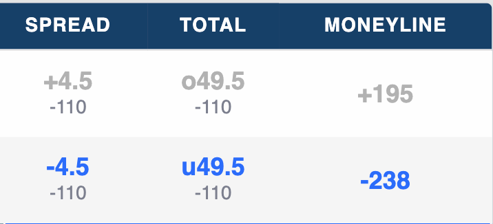

Pregame Betting Odds for the Above Matchup

Thanks to Scores and Odds for documenting those!

So, from the above, we can see that the spread set before the game had Philadelphia -4.5, which in other words means that they were 4.5 point favorites. So, for them to ‘cover the spread’, which they did, they had to win the game by at least five points. Another way to look at it is after the game is over, if you subtract 4.5 points from the Eagles score and they still win, then they cover the spread.

If you want to look at it the other way, the Commanders could have covered the spread if they had lost by 4 points or less. Or, if you *add* 4.5 points to the Commanders score after the game and they win, then they cover the spread.

Here we just edit the spread so it is just a positive number that we can use to compare to the score differential (favorited team - underdog) and if the spread is < the differential, then the spread hits.

```r
scores <- scores %>%
  mutate(spread_favorite = abs(spread_favorite))
```

Here is where we figure out if the spread hit or not, we first figure out who was favorited (home or away), then check the score differential (favorited team score - the underdog score) and if its greater than the line then we mark variable favorite_cover as 1 and 0 if not.

```r
scores <- scores %>%
  mutate(score_differential = abs(score_home - score_away)) %>%
  mutate(
    favorite_cover = case_when(
      team_favorite_id == home_id & score_home - score_away > spread_favorite ~ 1,   # home team favorite, and wins by more than the spread
      team_favorite_id == away_id & score_away - score_home > abs(spread_favorite) ~ 1,   # away team favorite, and wins by more than the spread
      TRUE ~ 0  # otherwise, the spread outcome is 0
    )
  )
```

Here, we also go ahead and mark if the moneyline bet for the favorited team hit, seeing if the favorited team scored more than the underdog. A moneyline bet in sports is the simplest bet, it is simply just outright picking who you think will win.

```r
scores <- scores %>%
  mutate(
    favorite_ML = case_when(
      favorite_cover == 1 ~ 1,
      team_favorite_id == home_id & score_home > score_away ~ 1,
      team_favorite_id == away_id & score_away > score_home ~ 1,
      TRUE ~ 0
    )
  )
```

Lastly, we join the offense and defense tables to the scores table, we do this such that home team offense stats are prefixed with home_offense, away teams offense is prefixed with away_offense and so on.

```r
scores <- scores %>%
  left_join(offense %>%
              rename_with(~ paste0("home_offense_", .), -c(team_id, schedule_season, Tm)) %>%
              select(-Tm),
            by = c("home_id" = "team_id", "schedule_season" = "schedule_season")) %>%

  left_join(defense %>%
              rename_with(~ paste0("home_defense_", .), -c(team_id, schedule_season, Tm)) %>%
              select(-Tm),
            by = c("home_id" = "team_id", "schedule_season" = "schedule_season")) %>%

  left_join(offense %>%
              rename_with(~ paste0("away_offense_", .), -c(team_id, schedule_season, Tm)) %>%
              select(-Tm),
            by = c("away_id" = "team_id", "schedule_season" = "schedule_season")) %>%

  left_join(defense %>%
              rename_with(~ paste0("away_defense_", .), -c(team_id, schedule_season, Tm)) %>%
              select(-Tm),
            by = c("away_id" = "team_id", "schedule_season" = "schedule_season"))
```

Now that we have the results of the bets from the scores, we can go back and drop the scores since we obviously won’t know that information when trying to predict before a game, as well as some other information to reduce the number of parameters we will have to feed the model to make predictions.

```r
ou_df <- scores %>%
  select(-c('schedule_date', 'score_home', 'score_away', 'score_differential', 'total_score', 'schedule_playoff', 'team_home', 'team_away')) %>%
  mutate(schedule_week = as.numeric(as.character(schedule_week))) %>%
  mutate(
    stadium_neutral = case_when(
      stadium_neutral == "FALSE" ~ 0,
      stadium_neutral == "TRUE" ~ 1
      )
    ) %>%
  mutate(team_favorite_id = as.factor(team_favorite_id)) %>%
  mutate(home_id = as.factor(home_id)) %>%
  mutate(away_id = as.factor(away_id)) %>%
  na.omit()
```

```r
favorite_ML_pos <- which(names(ou_df) == "favorite_ML")

ou_df <- ou_df %>%
  mutate(across((favorite_ML_pos + 1):ncol(ou_df), as.numeric))
```

# Building our models:

## Defining Model Success

Most of the time, we want a model to be 100% accurate. There is no exception to that here, however, we can also define another cutoff that we want our accuracy to fall above.

Many people that bet on sports have a saying that goes “52.4 is the most important number in sports betting”. This comes from the fact that, betting at a -110 line (you have to bet 110 dollars to win 100 dollars), which is typically the line of an over under bet, you would need to win 52.4% of your bets to be overall profitable. So, for the following models, we will use the the 52.4% accuracy cutoff to determine the fit of our model. The other thing you need to keep in mind within this setting is that it is very hard to accurately predict the outcomes of sporting events, even using the models below. [BettingPros](https://www.bettingpros.com/articles/what-is-the-break-even-win-for-sports-betting/), an online sports betting blog, explained this principle very well in the link that I attached.

## Over/Under Classification Models

Before we can begin to build our model, we of course need to split our data into a training and test set, along with removing the outcome columns.

```r
set.seed(123)
train_ind <- sample(1:nrow(ou_df), floor(0.8 * nrow(ou_df)))
Train <- ou_df[train_ind, ]
Test <- ou_df[-train_ind, ]
```

We go ahead and also remove the spread and moneyline columns and store those for later

```r
X_test_OU <- Test %>%
  select(-c(o_u_result, favorite_cover, favorite_ML))
y_test_OU <- Test %>%
  select(o_u_result)

Train_OU <- Train %>%
  select(-c(favorite_cover, favorite_ML))
```

### Using Random Forest:

```r
set.seed(380)
init_rf <- randomForest(as.factor(o_u_result) ~ ., data = Train_OU,
                   ntree = 500, mtry = 4)
```

```r
error <- init_rf$err.rate[, 1]  # error rate for each tree (for classification task)

# find number of trees where the error rate is minimized
optimal_ntree <- which.min(error)

# display optimal number of trees
print(optimal_ntree)
```

```
[1] 380
```

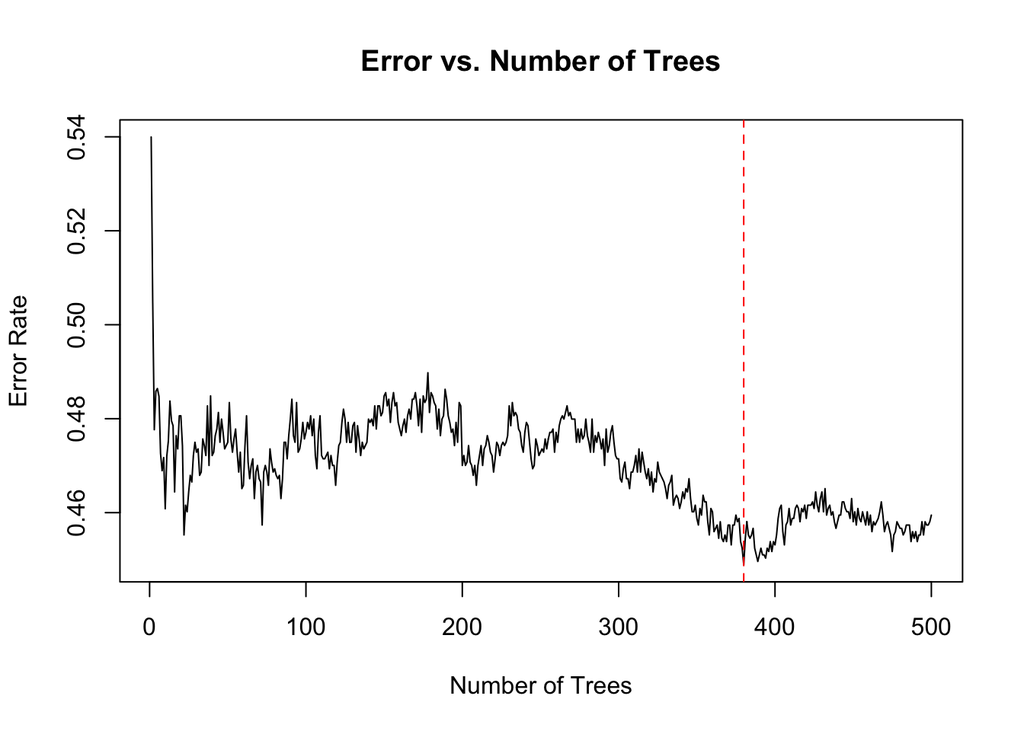

```r
# plot error rate vs. num trees to visualize the relationship
plot(error, type = "l", main = "Error vs. Number of Trees",
     xlab = "Number of Trees", ylab = "Error Rate")
abline(v = optimal_ntree, col = "red", lty = 2)
```

So, after using a high ntree value to see the biggest range of tree values to decide an optimal one, we can redefine our rf model with the number of trees that minimizes error, 380:

```r
rf <- randomForest(as.factor(o_u_result) ~ ., data = Train_OU,
                   ntree = 380, mtry = 4)
pred_prob1 <- predict(rf, newdata = X_test_OU, type = "prob")
head(pred_prob1)
```

```
           0         1
3  0.6236842 0.3763158
7  0.5315789 0.4684211
15 0.5000000 0.5000000
21 0.4421053 0.5578947
22 0.2947368 0.7052632
43 0.6157895 0.3842105
```

```r
pred_OU <- predict(rf, newdata = X_test_OU, type = "response")

table(pred_OU, y_test_OU$o_u_result)
```

```
pred_OU   0   1
      0  91  86
      1  75 103
```

```r
mean(pred_OU == y_test_OU$o_u_result)
```

```
[1] 0.5464789
```

From this, we can see that with an optimal random forest model, we have reached an accuracy of 54.65%, which is higher than the threshold we defined earlier for profitable betting. Let us now create another model using GBM.

### Using GBM:

First, let us tune the model using 5 fold cross validation:

```r
set.seed(380)

# define cross-validation
train_control <- trainControl(method = "cv",  # k-fold cross-validation
                              number = 5,     # 5 fold
                              verboseIter = TRUE)

# define the range of n.trees values to search over
tune_grid <- expand.grid(
  .n.trees = seq(0, 3000, by = 100),
  .interaction.depth = 2,
  .shrinkage = 0.001,
  .n.minobsinnode = 10
)

# train GBM model using 5 fold cross-validation
gbm_model_cv <- train(
  as.factor(o_u_result) ~ .,
  data = Train_OU,
  distribution = 'bernoulli',
  method = "gbm",
  trControl = train_control,
  tuneGrid = tune_grid,
  verbose = FALSE
)
# print the results of the cross-validation
print(gbm_model_cv)
```

```
Stochastic Gradient Boosting

1419 samples
 118 predictor
   2 classes: '0', '1'

No pre-processing
Resampling: Cross-Validated (5 fold)
Summary of sample sizes: 1134, 1135, 1136, 1136, 1135
Resampling results across tuning parameters:

  n.trees  Accuracy   Kappa
     0     0.5193800  0.000000000
   100     0.5200867  0.001527312
   200     0.5482758  0.065121958
   300     0.5560322  0.085901189
   400     0.5638060  0.105702262
   500     0.5659162  0.111580032
   600     0.5680438  0.117364346
   700     0.5631092  0.108952979
   800     0.5701392  0.124239550
   900     0.5645028  0.113537487
  1000     0.5673197  0.119849544
  1100     0.5687232  0.123458276
  1200     0.5687232  0.123952106
  1300     0.5680140  0.123344930
  1400     0.5687133  0.125311159
  1500     0.5680190  0.124236836
  1600     0.5687257  0.125636938
  1700     0.5708285  0.130441478
  1800     0.5715352  0.131925888
  1900     0.5729461  0.134955498
  2000     0.5694175  0.128142418
  2100     0.5701193  0.129814508
  2200     0.5708285  0.131410771
  2300     0.5708210  0.131595834
  2400     0.5694126  0.128753830
  2500     0.5729411  0.136125114
  2600     0.5729461  0.136137953
  2700     0.5729386  0.136416024
  2800     0.5729362  0.136606921
  2900     0.5736429  0.138188516
  3000     0.5764573  0.144256957

Tuning parameter 'interaction.depth' was held constant at a value of 2

Tuning parameter 'shrinkage' was held constant at a value of 0.001

Tuning parameter 'n.minobsinnode' was held constant at a value of 10
Accuracy was used to select the optimal model using the largest value.
The final values used for the model were n.trees = 3000, interaction.depth =
 2, shrinkage = 0.001 and n.minobsinnode = 10.
```

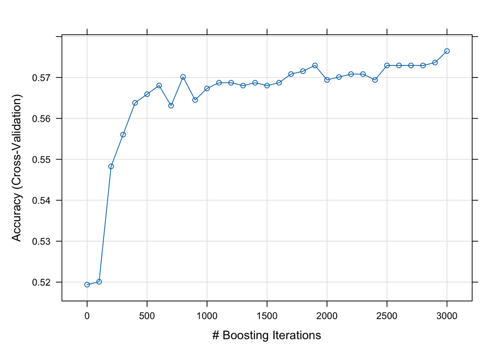

```r
# plot the # of iterations vs accuracy
plot(gbm_model_cv)
```

From the plot we see output above, we see that right around 1100 trees is where the accuracy begins to plateau, so to avoid overfitting, we will set our n.trees to 1100:

```r
set.seed(380)

gbm_model <- gbm(o_u_result ~ .,
                 data = Train_OU,
                 distribution = "bernoulli",
                 shrinkage = 0.001,
                 interaction.depth = 2,
                 n.minobsinnode = 10,
                 n.trees = 1100,
                 n.cores = NULL,
                 verbose = FALSE)

# predict probabilities
pred_prob_gbm <- predict(gbm_model, newdata = X_test_OU, type = "response")
```

```
Using 1100 trees...
```

```r
head(pred_prob_gbm)
```

```
[1] 0.4846582 0.4048665 0.5486889 0.5632436 0.4757064 0.4129929
```

```r
# make sure probabilities convert to class labels
pred_gbm <- ifelse(pred_prob_gbm > 0.5, 1, 0)

# evaluate metrics
table(pred_gbm, y_test_OU$o_u_result)  # confusion matrix
```

```
pred_gbm   0   1
       0 122 115
       1  44  74
```

```r
mean(pred_gbm == y_test_OU$o_u_result)  # accuracy
```

```
[1] 0.5521127
```

From the GBM model, we see we have generated an even higher accuracy than the random forest model, one of 55.21%.

### Predicting a recent game unknown to our model:

```r
# create a dataframe with info about the new game we want to try and predict
new_game <- data.frame(
  schedule_season = 2024,
  schedule_week = 11,
  team_favorite_id = "PHI",
  spread_favorite = 4.5,
  over_under_line = 49.5,
  stadium_neutral = 0,
  weather_temperature = 45,
  weather_wind_mph = 9,
  home_id = "PHI",
  away_id = "WAS"
)
```

```r
# join the additional features from offense and defense data according to teams and season year
new_game <- new_game %>%
  left_join(offense %>%
              rename_with(~ paste0("home_offense_", .), -c(team_id, schedule_season, Tm)) %>%
              select(-Tm),
            by = c("home_id" = "team_id", "schedule_season" = "schedule_season")) %>%
  left_join(defense %>%
              rename_with(~ paste0("home_defense_", .), -c(team_id, schedule_season, Tm)) %>%
              select(-Tm),
            by = c("home_id" = "team_id", "schedule_season" = "schedule_season")) %>%
  left_join(offense %>%
              rename_with(~ paste0("away_offense_", .), -c(team_id, schedule_season, Tm)) %>%
              select(-Tm),
            by = c("away_id" = "team_id", "schedule_season" = "schedule_season")) %>%
  left_join(defense %>%
              rename_with(~ paste0("away_defense_", .), -c(team_id, schedule_season, Tm)) %>%
              select(-Tm),
            by = c("away_id" = "team_id", "schedule_season" = "schedule_season"))
```

```r
# manipulating datatypes to make sure they match what the model was trained on
new_game <- new_game %>%
  mutate(schedule_season = as.integer(schedule_season)) %>%
  mutate(schedule_week = as.numeric(as.character(schedule_week))) %>%
  mutate(weather_temperature = as.integer(weather_temperature)) %>%
  mutate(weather_wind_mph = as.integer(weather_wind_mph)) %>%
  mutate(home_id = as.factor(home_id)) %>%
  mutate(away_id = as.factor(away_id)) %>%
  mutate(team_favorite_id = as.factor(team_favorite_id)) %>%
  mutate(home_id = as.factor(home_id)) %>%
  mutate(away_id = as.factor(away_id))

# make sure all offensive/defensive stats are numeric
away_id_pos <- which(names(new_game) == "away_id")
new_game <- new_game %>%
  mutate(across((away_id_pos + 1):ncol(new_game), as.numeric))
```

```r
# load the factor levels from training data to make sure the same amount of factor levels
train_levels <- list(
  home_id = levels(Train_OU$home_id),
  away_id = levels(Train_OU$away_id),
  team_favorite_id = levels(Train_OU$team_favorite_id)
)

new_game$home_id <- factor(new_game$home_id, levels = train_levels$home_id)
new_game$away_id <- factor(new_game$away_id, levels = train_levels$away_id)
new_game$team_favorite_id <- factor(new_game$team_favorite_id, levels = train_levels$team_favorite_id)
```

```r
# predict using our random forest model
pred_OU_rf <- predict(rf, newdata = new_game, type = "prob")
pred_OU_rf
```

```
          0         1
1 0.5105263 0.4894737
attr(,"class")
[1] "matrix" "array"  "votes"
```

```r
prob_under <- pred_OU_rf[1, 1]
prob_over <- pred_OU_rf[1, 2]

# make prediction based on which probability is higher
if (prob_over > prob_under) {
    predicted_class <- "Over"
    certainty <- prob_over
} else {
    predicted_class <- "Under"
    certainty <- prob_under
}
```

```r
cat("The prediction for the Over/Under with line set at",new_game$over_under_line[1], "using Gradient Boosting algorithm is that the", predicted_class, "will hit with", certainty, "% certainty.")
```

[output not shown]

```r
# predict using the gbm model
pred_OU_gbm <- predict(gbm_model, newdata = new_game, type = "response")
```

```
Using 1100 trees...
```

```r
predicted_prob <- pred_OU_gbm  # This value will be between 0 and 1
predicted_class <- ifelse(predicted_prob > 0.5, "Over", "Under")
ifelse(predicted_class == 'Under', predicted_certainty <- (1-predicted_prob) * 100, predicted_certainty <- (predicted_prob) * 100)
```

```
[1] 52.26261
```

```r
cat("The prediction for the Over/Under with line set at",new_game$over_under_line[1], "using Gradient Boosting algorithm is that the", predicted_class, "will hit with", predicted_certainty, "% certainty.")
```

```
The prediction for the Over/Under with line set at 49.5 using Gradient Boosting algorithm is that the Under will hit with 52.26261 % certainty.
```

Revisiting this game, which is the one that I used as a prior example to explain how spread betting works, we can see that the under did hit, and that both of our models predicted this correctly.

## XGboost

First we will create our model matrices to be able to be added into the xgboost function in R. We will also filter the test data for this model by filtering out columns.

```r
xgboosttest <- Test %>%
  select(-c(favorite_cover, favorite_ML))
xgboosttest <- xgboosttest[, -120]
train.mx <- sparse.model.matrix(o_u_result ~ ., Train_OU)[, -9]
test.mx <- sparse.model.matrix(o_u_result ~ ., xgboosttest)[, -9]

dtrain <- xgb.DMatrix(train.mx, label = Train_OU$o_u_result)
dtest <- xgb.DMatrix(test.mx, label = xgboosttest$o_u_result)
```

### Baseline Model

To fit the first XGboost model, we will select arbitrary baselines for each parameter. Later on, we will tune parameters for the XGboost model and compare perforamnce.

```r
xgboosttest$o_u_result <- as.factor(xgboosttest$o_u_result)

set.seed(123)
model_xgb <- xgboost(
  params = list(
    objective = "binary:logistic",
    eval_metric = 'auc',
    eta = 0.1,
    max_depth = 5,
    subsample = 0.8,
    colsample_bytree = 0.8),
  data = dtrain,
  nrounds = 100,
  early_stopping_rounds = 10,
  verbose = FALSE
)
preds <- predict(model_xgb, newdata = dtest)
auc(roc(predictor = preds, response = xgboosttest$o_u_result))
```

```
Area under the curve: 0.5661
```

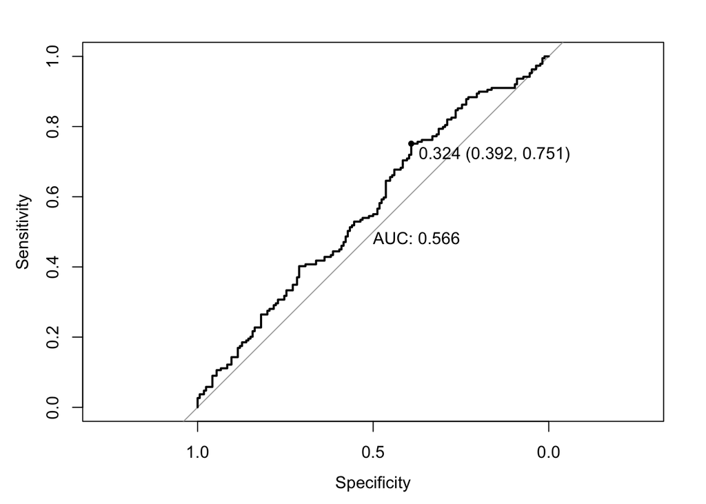

```r
plot(roc(predictor = preds, response = xgboosttest$o_u_result),
     print.thres = T, print.auc = T)
```

```r
xgboosttest$prediction <- ifelse(preds > 0.324, 1, 0)

mean(xgboosttest$o_u_result == xgboosttest$prediction)
```

```
[1] 0.5830986
```

### Hyperparameter Tuning

Now, we will tune hyperparameters. Due to time constraints and running time, we will reduce the number of hyperparameters tuned. A possible improvement in the future could be to tune more parameters for more values with more time and better resources. For the purposes of this project, the tuning below will be apt.

```r
xgboost_tune_grid <- expand.grid(gamma = c(0, 0.01, 0.1, 0.3),
                                 eta = c(0, 0.05),
                                 max_depth = 4,
                                 colsample_bytree = c(0.8, 1),
                                 nrounds = 50,
                                 subsample = c(0.8, 0.9, 1),
                                 min_child_weight = c(1,2,3))

xgboost_tune_control <- trainControl(method = "cv", number = 5,
                                     verboseIter = FALSE)


set.seed(380)
xgb_tune <- train(x = train.mx,
                  y = Train_OU$o_u_result,
                  trControl = xgboost_tune_control,
                  tuneGrid = xgboost_tune_grid,
                  objective = "binary:logistic",
                  eval_metric = 'auc',
                  method = "xgbTree",
                  verbosity = 0)
xgb_tune$bestTune
```

```
    nrounds max_depth  eta gamma colsample_bytree min_child_weight subsample
144      50         4 0.05   0.3                1                3         1
```

```r
final_model <- xgboost(
  params = list(
    objective = "binary:logistic",
    eval_metric = 'auc',
    eta = 0.05,
    gamma = 0.3,
    max_depth = 4,
    colsample_bytree = 1,
    min_child_weight = 3,
    subsample = 1),
  data = dtrain,
  nrounds = 50,
  early_stopping_rounds = 10,
  nfold = 10,
  verbose = FALSE
)


predsParamTune <- predict(final_model, newdata = dtest)
auc(roc(predictor = predsParamTune, response = xgboosttest$o_u_result))
```

```
Area under the curve: 0.5926
```

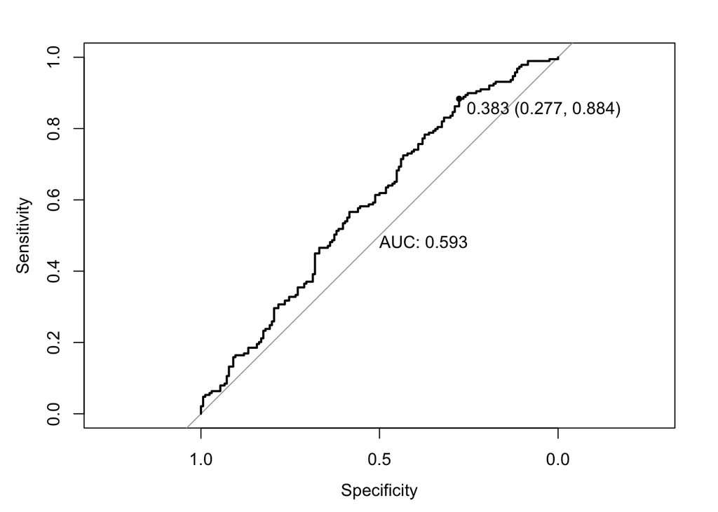

```r
plot(roc(predictor = predsParamTune, response = xgboosttest$o_u_result),
     print.thres = T, print.auc = T)
```

```r
xgboosttest$predictionTuning <- ifelse(predsParamTune > 0.383, 1, 0)

mean(xgboosttest$o_u_result == xgboosttest$predictionTuning)
```

```
[1] 0.6
```

The above model gives an accuracy of 60%, almost a 2% increase than the baseline model. We can also examine the AUC values for each model and further see the improvement of each model. In the first model, the AUC is about 0.56, and the tuned model achieves an AUC of 0.59. Now we can test the simplest model useable for our project, logistic regression.

## Logistic Regression

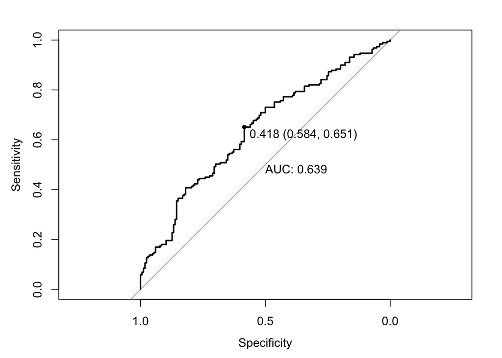

```r
# Logistic Regression
model_lr <- glm(factor(o_u_result) ~ ., data = Train_OU, family = binomial())
pred_lr <- predict(model_lr, newdata = xgboosttest, type = 'response')
plot(roc(response = xgboosttest$o_u_result, predictor = pred_lr, levels = 0:1, direction = '<'), print.auc = T, print.thres = T)
```

```r
mean(ifelse(pred_lr > 0.418, 1, 0) == xgboosttest$o_u_result)
```

```
[1] 0.6197183
```

From the above results, the logistic regression model achieves the highest accuracy of any model trained. This result could be for many reasons including the unpredictability of the NFL. The simplest model does not try to over emphasize any 1 parameter, while other models may pay more attention to certain predictors confusing the model. Another consideration when using the logistic regression model is multicollinearity, as many of our predictors may be naturally correlated.

### Predicting games for Sunday, 11/24/2024

Now, we will bump it up a notch and predict games for this coming Sunday, before they even happen. I have created an excel notebook which I have put in the info of every game this Sunday, and will read that in now and make sure the datatypes all match.

```r
week12_matchups <- read.csv("week12_matchups.csv")
```

```r
# join the additional features from offense and defense data according to teams and season year
week12_matchups <- week12_matchups %>%
  left_join(offense %>%
              rename_with(~ paste0("home_offense_", .), -c(team_id, schedule_season, Tm)) %>%
              select(-Tm),
            by = c("home_id" = "team_id", "schedule_season" = "schedule_season")) %>%
  left_join(defense %>%
              rename_with(~ paste0("home_defense_", .), -c(team_id, schedule_season, Tm)) %>%
              select(-Tm),
            by = c("home_id" = "team_id", "schedule_season" = "schedule_season")) %>%
  left_join(offense %>%
              rename_with(~ paste0("away_offense_", .), -c(team_id, schedule_season, Tm)) %>%
              select(-Tm),
            by = c("away_id" = "team_id", "schedule_season" = "schedule_season")) %>%
  left_join(defense %>%
              rename_with(~ paste0("away_defense_", .), -c(team_id, schedule_season, Tm)) %>%
              select(-Tm),
            by = c("away_id" = "team_id", "schedule_season" = "schedule_season"))
```

```r
# manipulating datatypes to make sure they match what the model was trained on
week12_matchups <- week12_matchups %>%
  mutate(schedule_season = as.integer(schedule_season)) %>%
  mutate(schedule_week = as.numeric(as.character(schedule_week))) %>%
  mutate(weather_temperature = as.integer(weather_temperature)) %>%
  mutate(weather_wind_mph = as.integer(weather_wind_mph)) %>%
  mutate(home_id = as.factor(home_id)) %>%
  mutate(away_id = as.factor(away_id)) %>%
  mutate(team_favorite_id = as.factor(team_favorite_id)) %>%
  mutate(home_id = as.factor(home_id)) %>%
  mutate(away_id = as.factor(away_id))

# make sure all offensive/defensive stats are numeric
away_id_pos <- which(names(week12_matchups) == "away_id")
week12_matchups <- week12_matchups %>%
  mutate(across((away_id_pos + 1):ncol(week12_matchups), as.numeric))
```

```r
# load the factor levels from training data to make sure the same amount of factor levels
train_levels <- list(
  home_id = levels(Train_OU$home_id),
  away_id = levels(Train_OU$away_id),
  team_favorite_id = levels(Train_OU$team_favorite_id)
)

week12_matchups$home_id <- factor(week12_matchups$home_id, levels = train_levels$home_id)
week12_matchups$away_id <- factor(week12_matchups$away_id, levels = train_levels$away_id)
week12_matchups$team_favorite_id <- factor(week12_matchups$team_favorite_id, levels = train_levels$team_favorite_id)
```

#### Predicting via random forest

```r
week12_pred_OU_rf <- predict(rf, newdata = week12_matchups, type = "prob")

# consolidate all predictions into a new dataframe
week12_under_class <- week12_pred_OU_rf[, 1]  # probs for class over
week12_over_class <- week12_pred_OU_rf[, 2]  # probs for class under
week12_rf_pred_OU <- ifelse(week12_over_class > 0.5, "Over", "Under")
week12_rf_pred_prob <- ifelse(week12_rf_pred_OU == "Over", round(week12_over_class*100,3), round(week12_under_class*100,3))

rf_prediction_df <- data.frame(
  Home = week12_matchups$home_id,
  Away = week12_matchups$away_id,
  Line = week12_matchups$over_under_line,
  Prediction = week12_rf_pred_OU,            # prediction: Over or Under
  Confidence = week12_rf_pred_prob           # probability associated with the predicted outcome
)

rf_prediction_df %>%
  kable(format = "html", caption = "<span style='color: black;'>O/U Predictions for Week 12 Games By Random Forest Algorithm") %>%
  kable_styling(bootstrap_options = c("striped", "hover", "condensed"), full_width = FALSE) %>%
  column_spec(4, bold = TRUE, color = "white", background = "#0073e6") %>%
  column_spec(5, bold = TRUE, color = "black", background = "#f0f0f0") %>%
  add_header_above(c("Game Information" = 3, "Prediction" = 2))
```

O/U Predictions for Week 12 Games By Random Forest Algorithm

| Game Information Home | Game Information Away | Game Information Line | Prediction | Prediction Confidence |
| --- | --- | --- | --- | --- |
| CAR | KC | 43.5 | Over | 53.947 |
| CHI | MIN | 39.5 | Over | 59.474 |
| HOU | TEN | 40.5 | Under | 81.316 |
| IND | DET | 50.5 | Over | 50.789 |
| MIA | NE | 46.5 | Under | 55.526 |
| NYG | TB | 41.5 | Over | 64.211 |
| WAS | DAL | 44.5 | Over | 50.263 |
| LVR | DEN | 41.5 | Over | 69.737 |
| GB | SF | 45.5 | Under | 56.579 |
| SEA | ARI | 47.5 | Under | 53.947 |
| LAR | PHI | 48.5 | Over | 51.316 |
| LAC | BAL | 50.5 | Under | 55.526 |

Now lets find the games with the three highest confidence for the predictions.

```r
top_rf_locks <- rf_prediction_df %>%
  arrange(desc(`Confidence`)) %>%
  head(3) %>%
  select(Home, Away, `Prediction`)
top_rf_locks
```

```
  Home Away Prediction
3  HOU  TEN      Under
8  LVR  DEN       Over
6  NYG   TB       Over
```

So, according to the random forest algorithm, the three games that we should bet money on the most (highest probability of going one way or the other), are Tennessee @ Houston, Denver @ Las Vegas, and Tampa Bay @ New York Giants.

#### Predicting via gradient boosting

```r
week12_pred_OU_gbm <- predict(gbm_model, newdata = week12_matchups, type = "response")
```

```
Using 1100 trees...
```

```r
week12_gbm_pred_OU <- ifelse(week12_pred_OU_gbm > 0.5, "Over", "Under")
week12_gbm_pred_prob <- ifelse(week12_gbm_pred_OU == "Over", round(week12_pred_OU_gbm*100,3), round((1-week12_pred_OU_gbm)*100,3))


gbm_prediction_df <- data.frame(
  Home = week12_matchups$home_id,
  Away = week12_matchups$away_id,
  Line = week12_matchups$over_under_line,
  Prediction = week12_gbm_pred_OU,            # prediction: Over or Under
  Confidence = week12_gbm_pred_prob           # probability associated with the predicted outcome
)

gbm_prediction_df %>%
  kable(format = "html", caption = "<span style='color: black;'>O/U Predictions for Week 12 Games By Gradient Boosting Algorithm") %>%
  kable_styling(bootstrap_options = c("striped", "hover", "condensed"), full_width = FALSE) %>%
  column_spec(4, bold = TRUE, color = "white", background = "#0073e6") %>%
  column_spec(5, bold = TRUE, color = "black", background = "#f0f0f0") %>%
  add_header_above(c("Game Information" = 3, "Prediction" = 2))
```

O/U Predictions for Week 12 Games By Gradient Boosting Algorithm

| Game Information Home | Game Information Away | Game Information Line | Prediction | Prediction Confidence |
| --- | --- | --- | --- | --- |
| CAR | KC | 43.5 | Under | 50.041 |
| CHI | MIN | 39.5 | Under | 55.474 |
| HOU | TEN | 40.5 | Under | 61.124 |
| IND | DET | 50.5 | Under | 57.636 |
| MIA | NE | 46.5 | Under | 51.724 |
| NYG | TB | 41.5 | Under | 50.795 |
| WAS | DAL | 44.5 | Under | 54.311 |
| LVR | DEN | 41.5 | Under | 53.484 |
| GB | SF | 45.5 | Over | 52.053 |
| SEA | ARI | 47.5 | Over | 52.079 |
| LAR | PHI | 48.5 | Under | 51.833 |
| LAC | BAL | 50.5 | Under | 55.164 |

We can also find the top three games with the highest confidence like we did for random forest

```r
top_gbm_locks <- gbm_prediction_df %>%
  arrange(desc(`Confidence`)) %>%
  head(3) %>%
  select(Home, Away, `Prediction`)
top_gbm_locks
```

```
  Home Away Prediction
1  HOU  TEN      Under
2  IND  DET      Under
3  CHI  MIN      Under
```

So according to the gradient boosting algorithm, the top games to bet on are Tennessee @ Houston, Detroit @ Indianapolis, and Minnesota @ Chicago.

#### Predicting via XGBoost:

Repeating the same process seen in the previous model predictions:

First, because of the way that XGBoost model works, we have to first create a matrix with the week 12 matchup infor, then it is the same process

```r
week12.mx <- sparse.model.matrix(~ ., data = week12_matchups)
train_columns <- colnames(dtrain)
# ensure only the common columns remain
week12.mx <- week12.mx[, colnames(week12.mx) %in% train_columns]
week12_dmatrix <- xgb.DMatrix(week12.mx)
```

```r
# make predictions using the trained XGBoost model on the new data
week12_pred_OU_xgb <- predict(final_model, newdata = week12_dmatrix)

# convert the probabilities to "Over" or "Under" based on a threshold
week12_xgb_pred_OU <- ifelse(week12_pred_OU_xgb > 0.383, "Over", "Under")

week12_xgb_pred_prob <- ifelse(week12_xgb_pred_OU == "Over",
                               round((0.5+(week12_pred_OU_xgb - 0.383))*100,3),
                               round((0.5+(0.383 - week12_pred_OU_xgb))*100,3)
                               )


# Consolidate the predictions into a new dataframe
xgb_prediction_df <- data.frame(
  Home = week12_matchups$home_id,   # home team ID
  Away = week12_matchups$away_id,   # away team ID
  Line = week12_matchups$over_under_line,  # Over/Under line
  Prediction = week12_xgb_pred_OU,  # prediction: "Over" or "Under"
  Confidence = week12_xgb_pred_prob # probability based off predict output
)

# display the predictions in a nicely formatted table using kable
xgb_prediction_df %>%
  kable(format = "html", caption = "<span style='color: black;'>O/U Predictions for Week 12 Games By XGBoost Model") %>%
  kable_styling(bootstrap_options = c("striped", "hover", "condensed"), full_width = FALSE) %>%
  column_spec(4, bold = TRUE, color = "white", background = "#0073e6") %>%
  column_spec(5, bold = TRUE, color = "black", background = "#f0f0f0") %>%
  add_header_above(c("Game Information" = 3, "Prediction" = 2))
```

O/U Predictions for Week 12 Games By XGBoost Model

| Game Information Home | Game Information Away | Game Information Line | Prediction | Prediction Confidence |
| --- | --- | --- | --- | --- |
| CAR | KC | 43.5 | Over | 64.863 |
| CHI | MIN | 39.5 | Over | 56.473 |
| HOU | TEN | 40.5 | Under | 53.261 |
| IND | DET | 50.5 | Over | 53.226 |
| MIA | NE | 46.5 | Under | 50.659 |
| NYG | TB | 41.5 | Over | 50.864 |
| WAS | DAL | 44.5 | Over | 57.305 |
| LVR | DEN | 41.5 | Over | 64.945 |
| GB | SF | 45.5 | Under | 50.089 |
| SEA | ARI | 47.5 | Over | 54.099 |
| LAR | PHI | 48.5 | Over | 54.478 |
| LAC | BAL | 50.5 | Under | 60.572 |

Due to the nature of the XGBoost algorithm and how the cutoff is at 0.383 for the most accurate predictions, and not just 0.5, it is very hard to quantify the confidence (proability), so for this table, we have had to do some feature engineering for most accurate confidence levels scaled at a reasonable value.

Doing the same thing to find the three best bets:

```r
top_xgb_locks <- xgb_prediction_df %>%
  arrange(desc(`Confidence`)) %>%
  head(3) %>%
  select(Home, Away, `Prediction`)
top_xgb_locks
```

```
  Home Away Prediction
1  LVR  DEN       Over
2  CAR   KC       Over
3  LAC  BAL      Under
```

#### Predicting via Logistic Regression:

Finally, doing the same predictions with the logistic regression model:

```r
week12_pred_OU_logit <- predict(model_lr, newdata = week12_matchups, type = "response")
# convert the probabilities to "Over" or "Under" based on a threshold
week12_logit_pred_OU <- ifelse(week12_pred_OU_logit > 0.418, "Over", "Under")

week12_logit_pred_prob <- ifelse(week12_logit_pred_OU == "Over",
                               round((0.5+(week12_pred_OU_logit - 0.418))*100,3),
                               round((0.5+(0.418 - week12_pred_OU_logit))*100,3)
                               )


# Consolidate the predictions into a new dataframe
logit_prediction_df <- data.frame(
  Home = week12_matchups$home_id,   # home team ID
  Away = week12_matchups$away_id,   # away team ID
  Line = week12_matchups$over_under_line,  # Over/Under line
  Prediction = week12_logit_pred_OU,  # prediction: "Over" or "Under"
  Confidence = week12_logit_pred_prob # probability based off of prediction output
)

# display the predictions in a nicely formatted table using kable
logit_prediction_df %>%
  kable(format = "html", caption = "<span style='color: black;'>O/U Predictions for Week 12 Games By Logistic Regression Model") %>%
  kable_styling(bootstrap_options = c("striped", "hover", "condensed"), full_width = FALSE) %>%
  column_spec(4, bold = TRUE, color = "white", background = "#0073e6") %>%
  column_spec(5, bold = TRUE, color = "black", background = "#f0f0f0") %>%
  add_header_above(c("Game Information" = 3, "Prediction" = 2))
```

O/U Predictions for Week 12 Games By Logistic Regression Model

| Game Information Home | Game Information Away | Game Information Line | Prediction | Prediction Confidence |
| --- | --- | --- | --- | --- |
| CAR | KC | 43.5 | Over | 96.712 |
| CHI | MIN | 39.5 | Over | 50.317 |
| HOU | TEN | 40.5 | Under | 90.939 |
| IND | DET | 50.5 | Over | 71.068 |
| MIA | NE | 46.5 | Under | 70.419 |
| NYG | TB | 41.5 | Over | 61.080 |
| WAS | DAL | 44.5 | Under | 75.454 |
| LVR | DEN | 41.5 | Over | 67.572 |
| GB | SF | 45.5 | Over | 50.874 |
| SEA | ARI | 47.5 | Over | 94.116 |
| LAR | PHI | 48.5 | Under | 85.279 |
| LAC | BAL | 50.5 | Under | 57.993 |

And as well, find the highest confidence games

```r
top_logit_locks <- logit_prediction_df %>%
  arrange(desc(`Confidence`)) %>%
  head(3) %>%
  select(Home, Away, `Prediction`)
top_logit_locks
```

```
   Home Away Prediction
1   CAR   KC       Over
10  SEA  ARI       Over
3   HOU  TEN      Under
```

#### Prediction Results:

Now, lets compare our models to the actual result of these games:

First, let us create and read in a dataframe with the actual O/U results:

```r
week12_outcomes <- read.csv("week12_outcomes.csv")
```

```r
# merge the week12_outcomes dataframe with all prediction dataframes

merged_df <- week12_outcomes %>%
  left_join(select(rf_prediction_df, Home, Away, Prediction), by = c("Home", "Away")) %>%
  rename("RF Prediction" = Prediction) %>%
  left_join(select(gbm_prediction_df, Home, Away, Prediction), by = c("Home", "Away")) %>%
  rename("GBM Prediction" = Prediction) %>%
  left_join(select(xgb_prediction_df, Home, Away, Prediction), by = c("Home", "Away")) %>%
  rename("XGBoost Prediction" = Prediction) %>%
  left_join(select(logit_prediction_df, Home, Away, Prediction), by = c("Home", "Away")) %>%
  rename("Logistic Regression Prediction" = Prediction)

# create a formatted table with conditional coloring based on prediction match
merged_df %>%
  kable(format = "html", caption = "<span style='color: black;'>Week 12 Predictions vs Actual Outcomes") %>%
  kable_styling(bootstrap_options = c("striped", "hover", "condensed"), full_width = FALSE) %>%
  column_spec(4, bold = TRUE, color = "white", background = "#0073e6") %>%
  # apply green or red background color for prediction matches
  column_spec(5, background = case_when(
    merged_df$`RF Prediction` == merged_df$Outcome ~ "rgba(0, 255, 0, 0.8)",
    merged_df$`RF Prediction` != merged_df$Outcome ~ "rgba(255, 0, 0, 0.8)"
  )) %>%
  column_spec(6, background = case_when(
    merged_df$`GBM Prediction` == merged_df$Outcome ~ "rgba(0, 255, 0, 0.8)",
    merged_df$`GBM Prediction` != merged_df$Outcome ~ "rgba(255, 0, 0, 0.8)"
  )) %>%
  column_spec(7, background = case_when(
    merged_df$`XGBoost Prediction` == merged_df$Outcome ~ "rgba(0, 255, 0, 0.8)",
    merged_df$`XGBoost Prediction` != merged_df$Outcome ~ "rgba(255, 0, 0, 0.8)"
  )) %>%
  column_spec(8, background = case_when(
    merged_df$`Logistic Regression Prediction` == merged_df$Outcome ~ "rgba(0, 255, 0, 0.8)",
    merged_df$`Logistic Regression Prediction` != merged_df$Outcome ~ "rgba(255, 0, 0, 0.8)"
  )) %>%
  add_header_above(c("Game Information" = 4, "Model Outcomes" = 4))
```

Week 12 Predictions vs Actual Outcomes

| Game Information Home | Game Information Away | Game Information Line | Game Information Outcome | Model Outcomes RF Prediction | Model Outcomes GBM Prediction | Model Outcomes XGBoost Prediction | Model Outcomes Logistic Regression Prediction |
| --- | --- | --- | --- | --- | --- | --- | --- |
| CAR | KC | 43.5 | Over | Over | Under | Over | Over |
| CHI | MIN | 39.5 | Over | Over | Under | Over | Over |
| HOU | TEN | 40.5 | Over | Under | Under | Under | Under |
| IND | DET | 50.5 | Under | Over | Under | Over | Over |
| MIA | NE | 46.5 | Over | Under | Under | Under | Under |
| NYG | TB | 41.5 | Under | Over | Under | Over | Over |
| WAS | DAL | 44.5 | Over | Over | Under | Over | Under |
| LVR | DEN | 41.5 | Over | Over | Under | Over | Over |
| GB | SF | 45.5 | Over | Under | Over | Under | Over |
| SEA | ARI | 47.5 | Under | Under | Over | Over | Over |
| LAR | PHI | 48.5 | Over | Over | Under | Over | Under |
| LAC | BAL | 50.5 | Over | Under | Under | Under | Under |

# Limitations

There are many areas of our project than can be described as limitations. The nature of the NFL is one, where so many different things can determine the outcome of a game. The most important one is that NFL players are humans, and show human emotions week-to-week that may change over the course of an NFL season. There are countless examples including momentum, as a team playing well may continue to play well, or perhaps a team has a lt down game where they fail to achieve the results they had been known to achieve. There are also other observations for which we do not have the current data for, such as major injuries and number of injuries for a team. Offseason player movement and trades is another area that could influence week-to-week changes or seasonal changes. Through all of these limitations, our models were still able to perform at a level that can be effectively used.

Another potential area to explore is the use of every predictor in our models. Some predictors may not be as effective as others in the model and may even point the model in the wrong direction. In the future, variable selection methods could be explored to further enhance the performance of our models. Also, as mentioned earlier in this project the tuning of hyperparameters was used to improve prediction accuracy. The scope of tuning of these parameters was relatively small and could be widened in the future at the cost of deficiency and runtime. Clearly, this project still has possibilities to expand and become even more effective.

# Conclusion and Discussion